# Chapter 3 HW

Caijun Qin

10/13/2021

Install packages.

```r
packages <- c('boot', 'caret', 'comprehenr', 'e1071', 'ggplot2', 'MASS')
install.packages(packages)
lapply(packages, library, character.only = TRUE)
```

```
## [[1]]
## [1] "boot"      "stats"     "graphics"  "grDevices" "utils"     "datasets"
## [7] "methods"   "base"
##
## [[2]]
##  [1] "caret"     "lattice"   "ggplot2"   "boot"      "stats"     "graphics"
##  [7] "grDevices" "utils"     "datasets"  "methods"   "base"
##
## [[3]]
##  [1] "comprehenr" "caret"      "lattice"    "ggplot2"    "boot"
##  [6] "stats"      "graphics"   "grDevices"  "utils"      "datasets"
## [11] "methods"    "base"
##
## [[4]]
##  [1] "e1071"      "comprehenr" "caret"      "lattice"    "ggplot2"
##  [6] "boot"       "stats"      "graphics"   "grDevices"  "utils"
## [11] "datasets"   "methods"    "base"
##
## [[5]]
##  [1] "e1071"      "comprehenr" "caret"      "lattice"    "ggplot2"
##  [6] "boot"       "stats"      "graphics"   "grDevices"  "utils"
## [11] "datasets"   "methods"    "base"
##
## [[6]]
##  [1] "MASS"       "e1071"      "comprehenr" "caret"      "lattice"
##  [6] "ggplot2"    "boot"       "stats"      "graphics"   "grDevices"
## [11] "utils"      "datasets"   "methods"    "base"
```

Question 1 Question 1i

Rgw dataset from `Crabs.dat` comprises of both numerical and nominal variables. The output y, color, and spine are intuitively categorical although they are presented as integers initially. These 3 variables (the last 2 being predictors) are wrapped with `factor` in the formula for statistical models. Some models such as decision trees can handle both numerical and nominal variables together naturally as it uses thresholds to split numerical variables into 2 ranges and nominal variables into 2 groups of indicator values. Other methods such as KNN classify based on a distance metric does not immediately handle nominal variables as straightforward. You can always replace nominal variables with indicator variables or one-hot encoding before running KNN.

```r
# read in data
crabs <- read.table(file = 'Data/Crabs.dat', header = TRUE)
head(x = crabs)
```

```
##   y weight width color spine
## 1 1   3.05  28.3     2     3
## 2 0   1.55  22.5     3     3
## 3 1   2.30  26.0     1     1
## 4 0   2.10  24.8     3     3
## 5 1   2.60  26.0     3     3
## 6 0   2.10  23.8     2     3
```

```r
length(x = crabs$y)
```

```
## [1] 173
```

```r
crabs_formula <- factor(x = y) ~ factor(x = color) + factor(x = spine) + .
crabs_formula
```

```
## factor(x = y) ~ factor(x = color) + factor(x = spine) + .
```

Question 1ii

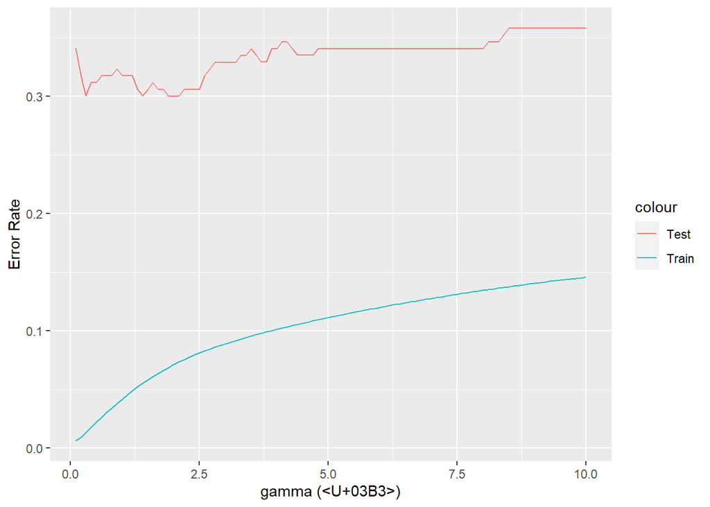

```r
# radial SVM
svm_radial_tuned.test <- e1071::tune.svm(
  crabs_formula,
  data = crabs,
  kernel = 'radial',
  gamma = seq(0.1, 10.0, by = 0.1),
  tunecontrol = tune.control(cross = 2)
)

train.index <- unlist(x = svm_radial_tuned.test$train.ind$`(0.828,87]`)

svm_radial_tuned.train <- e1071::tune.svm(
  x = crabs[train.index, ],
  y = crabs[train.index, ]$y,
  crabs_formula,
  kernel = 'radial',
  gamma = seq(0.1, 10.0, by = 0.1)
)

ggplot() + geom_line(
  data = svm_radial_tuned.train$performances,
  aes(
    x = gamma,
    y = error,
    color = 'Train'
  )
) + geom_line(
  data = svm_radial_tuned.test$performances,
  aes(
    x = gamma,
    y = error,
    color = 'Test'
  )
) + xlab(label = 'gamma (γ)') + ylab(label = 'Error Rate')
```

Model starts to overfit immediately and retains a huge gap between train and test error rates with varying gamma.

Question 1iii

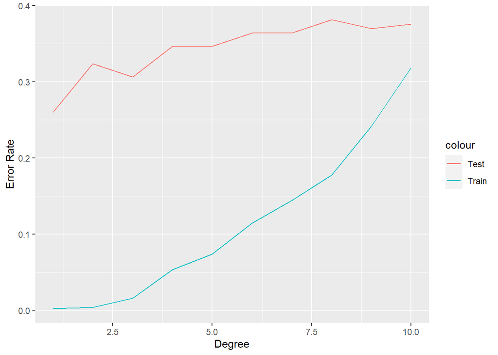

```r
# polynomial SVM
svm_poly_tuned.test <- e1071::tune.svm(
  crabs_formula,
  data = crabs,
  kernel = 'poly',
  degree = 1:10,
  tunecontrol = tune.control(cross = 2)
)

train.index <- unlist(x = svm_poly_tuned.test$train.ind$`(0.828,87]`)

svm_poly_tuned.train <- e1071::tune.svm(
  x = crabs[train.index, ],
  y = crabs[train.index, ]$y,
  crabs_formula,
  kernel = 'poly',
  degree = 1:10
)

ggplot() + geom_line(
  data = svm_poly_tuned.train$performances,
  aes(
    x = degree,
    y = error,
    color = 'Train'
  )
) + geom_line(
  data = svm_poly_tuned.test$performances,
  aes(
    x = degree,
    y = error,
    color = 'Test'
  )
) + xlab(label = 'Degree') + ylab(label = 'Error Rate')
```

Question 1 iv

```r
window <- as.integer(x = length(x = crabs$y) / 10) # sliding window to extract test indexes
k.range <- 1:50 # values of k for parameter tuning
knn.err.df <- as.data.frame(
  x = matrix(data = rep(x = 0.0, times = length(x = k.range) * 10), nrow = length(x = k.range)),
  row.names = k.range
)
colnames(knn.err.df) <- comprehenr::to_vec(for (i in 1:10) sprintf('cv%d', i))

# creates vector of error rates for a specific k for KNN with cross-validation folds
knn.cv <- function(k, cv_folds) {
  comprehenr::to_vec(
    for (cv in 1:cv_folds) {
      # print(cv)
      test.index <- c(1:window) + (cv - 1) * window
      test.data <- crabs[test.index, ]
      train.data <- crabs[-test.index, ]
      knn.model <- caret::train(
        form = crabs_formula,
        data = train.data,
        method = 'knn',
        preProcess = c("center","scale"),
        tuneGrid=data.frame(k=k)
      )
      knn.pred <- predict(object = knn.model, newdata = test.data[, -y])
      knn.pred

      cm <- caret::confusionMatrix(
        data = factor(x = knn.pred),
        reference = factor(x = test.data$y)
      )

      err.rate <- 1 - sum(... = diag(x = prop.table(cm$table)))
      err.rate
    }
  )
}

# filling up k x CV dataframe for error rates
for (k in k.range) {
  # print(k)
  knn.err.df[k, ] <- knn.cv(k = k, cv_folds = 10)
}
```

```
## Error in `[.data.frame`(test.data, , -y): object 'y' not found
```

[figure not shown]

```r
knn.cv.means <- rowMeans(x = knn.err.df)
ggplot() + geom_line(aes(x = k.range, y = knn.cv.means)) + scale_x_continuous(breaks = seq(0, 100, 10)) + xlab(label = 'k') + ylab(label = 'Mean Error Rate')
```

Question 1 v

```r
# computes error rate
err.rate.func <- function(table) {
  1 - sum(... = diag(x = prop.table(table)))
}

model.err.df <- as.data.frame(x = matrix(data = rep(x = 0.0, times = 100 * 5), nrow = 100))
colnames(x = model.err.df) <- c('LDA', 'QDA', 'KNN', 'SVM.radial', 'SVM.poly')

# comparing multiple models
for (i in 1:100) {
  validation.index <- sample(x = c(1:length(x = crabs$y)), size = 25, replace = FALSE)
  validation.data <- crabs[validation.index, ]
  train.data <- crabs[-validation.index, ]

  # different models
  # LDA
  lda.model <- MASS::lda(formula = crabs_formula, data = train.data)

  pred <- as.numeric(
  x = predict(
    object = lda.model,
    newdata = validation.data[, -y],
    type = 'class')$class
  ) - 1

  model.err.df[i, 'LDA'] <- err.rate.func(table = caret::confusionMatrix(
        data = factor(x = pred),
        reference = factor(x = validation.data$y)
      )$table)

  # QDA
  qda.model <- MASS::qda(formula = y ~ ., data = train.data)

  pred <- as.numeric(
    x = predict(
      object = qda.model,
      newdata = validation.data[, -y],
      type = 'class')$class
    ) - 1

  model.err.df[i, 'QDA'] <- err.rate.func(table = caret::confusionMatrix(
        data = factor(x = pred),
        reference = factor(x = validation.data$y)
      )$table)

  # KNN
  knn.model <- e1071::tune.knn(x = train.data[, -y], y = as.factor(x = train.data$y), data = train.data, k = 1:50)

  pred <- as.integer(
    x = predict(
    object = e1071::gknn(
      x = train.data[, -y],
      y = as.factor(x = train.data$y),
      k = unlist(knn.model$best.parameters)),
    newdata = validation.data[, -y],
  type = 'class')) - 1

  model.err.df[i, 'KNN'] <- err.rate.func(table = caret::confusionMatrix(
        data = factor(x = pred),
        reference = factor(x = validation.data$y)
      )$table)

  # SVM radial kernel
  svm.radial.model <- e1071::tune.svm(x = train.data[, -y], y = as.factor(x = train.data$y), kernel = 'radial', gamma =  seq(0.1, 10.0, by = 0.1))

  pred <- as.numeric(
    x = predict(object = e1071::svm(
      x = train.data[, -y],
      y = as.factor(train.data$y),
      gamma = svm.radial.model$best.parameters
    ),
    newdata = validation.data[, -y], type = 'class')
  ) - 1

  model.err.df[i, 'SVM.radial'] <- err.rate.func(table = caret::confusionMatrix(
        data = factor(x = pred),
        reference = factor(x = validation.data$y)
      )$table)

  # SVM polynomial kernel
  svm.poly.model <- e1071::tune.svm(x = train.data[, -y], y = as.factor(x = train.data$y), kernel = 'poly', degree = 1:10)

  pred <- as.numeric(
    x = predict(object = e1071::svm(
      x = train.data[, -y],
      y = as.factor(train.data$y),
      degree = svm.poly.model$best.parameters
    ),
    newdata = validation.data[, -y], type = 'class')
  ) - 1

  model.err.df[i, 'SVM.poly'] <- err.rate.func(table = caret::confusionMatrix(
        data = factor(x = pred),
        reference = factor(x = validation.data$y)
      )$table)
}
```

```
## Error in `[.data.frame`(validation.data, , -y): object 'y' not found
```

[figure not shown]

```r
# model.err.df

library(ggplot2)
ggplot(stack(model.err.df), aes(x = ind, y = values)) +
  geom_boxplot() + xlab(label = 'Models') + ylab(label = 'Error Rates')
```

Question 2 i

Since we know the distribution of X_i follows a uniform distribution exactly and the domain being integers confined to [0, 10], q_0.8, or the 80th percentile, is simply the CDF of the uniform distribution taken at 0.80. The value comes out to be 8.

Question 2 ii

A good estimator for q_0.8 would be the corresponding statistic, in this case 80th percentile, of the sample of X_i. Following convention, this would usually be denoted as q_0.8 ^ hat.

Question 2 iii

```r
R <- 10 # number of resamples

# computes whether number is inside interval
inside.interval <- function(x, interval, inclusive = TRUE) {
  if (inclusive) {
    return (x >= min(interval) & x <= max(interval))
  }
  x > min(interval) & x < max(interval)
}

# function to compute statistic i.e. q_0.8
q_eighty <- function(data, indices) {
  bootstrap.sample <- data[indices]
  quantile(x = bootstrap.sample, probs = c(0.80))
}

# bootstrapping
boot.data <- sort(x = rep(x = c(1:10), times = 10))
boot.result <- boot::boot(data = boot.data, statistic = q_eighty, R = R)
boot.result
```

```
##
## ORDINARY NONPARAMETRIC BOOTSTRAP
##
##
## Call:
## boot::boot(data = boot.data, statistic = q_eighty, R = R)
##
##
## Bootstrap Statistics :
##     original  bias    std. error
## t1*      8.2     0.1   0.6749486
```

```r
# plot(boot.result)

# confidence intervals
boot.conf.intervals <- boot::boot.ci(boot.out = boot.result, conf = 0.95, type = c('perc', 'norm'))
boot.conf.intervals
```

```
## BOOTSTRAP CONFIDENCE INTERVAL CALCULATIONS
## Based on 10 bootstrap replicates
##
## CALL :
## boot::boot.ci(boot.out = boot.result, conf = 0.95, type = c("perc",
##     "norm"))
##
## Intervals :
## Level      Normal             Percentile
## 95%   ( 6.777,  9.423 )   ( 7.000,  9.000 )
## Calculations and Intervals on Original Scale
## Warning : Percentile Intervals used Extreme Quantiles
## Some percentile intervals may be unstable
```

Question 2 iv

```r
parallel.packages <- c('parallel', 'doParallel', 'foreach', 'snow')
install.packages(parallel.packages)
lapply(parallel.packages, library, character.only = TRUE)
```

```
## [[1]]
##  [1] "parallel"   "MASS"       "e1071"      "comprehenr" "caret"
##  [6] "lattice"    "ggplot2"    "boot"       "stats"      "graphics"
## [11] "grDevices"  "utils"      "datasets"   "methods"    "base"
##
## [[2]]
##  [1] "doParallel" "iterators"  "foreach"    "parallel"   "MASS"
##  [6] "e1071"      "comprehenr" "caret"      "lattice"    "ggplot2"
## [11] "boot"       "stats"      "graphics"   "grDevices"  "utils"
## [16] "datasets"   "methods"    "base"
##
## [[3]]
##  [1] "doParallel" "iterators"  "foreach"    "parallel"   "MASS"
##  [6] "e1071"      "comprehenr" "caret"      "lattice"    "ggplot2"
## [11] "boot"       "stats"      "graphics"   "grDevices"  "utils"
## [16] "datasets"   "methods"    "base"
##
## [[4]]
##  [1] "snow"       "doParallel" "iterators"  "foreach"    "parallel"
##  [6] "MASS"       "e1071"      "comprehenr" "caret"      "lattice"
## [11] "ggplot2"    "boot"       "stats"      "graphics"   "grDevices"
## [16] "utils"      "datasets"   "methods"    "base"
```

```r
# TRUE or FALSE? normal CI for each specific resample covers true parameter
# boot.coverage <- function(parameter, z, std.err) {
#   comprehenr::to_vec(
#     for (t in as.vector(x = boot.result$t)) {
#       ci <- t + z * std.err * c(-1, 1)
#       inside.interval(x = parameter, interval = ci)
#     }
#   )
# }

# multiprocessing setup
ncores <- parallel::detectCores()
cluster <- parallel::makeCluster(spec = ncores - 1, type = 'SOCK', methods = FALSE)
parallel::setDefaultCluster(cl = cluster)
doParallel::registerDoParallel(cl = cluster)

nsim <- 1000 # nubmer of simulation trials

# compute proportion of percentile CIs that cover true parameter
x <- quantile(x = boot.data, probs = c(0.80))
boot.coverage.perc <- unlist(x = foreach::foreach (i = 1:nsim) %dopar% {

  # bootstrap resampling
  boot.result <- boot::boot(data = boot.data, statistic = q_eighty, R = R)

  # CIs
  boot.conf.intervals <- boot::boot.ci(boot.out = boot.result, conf = 0.95, type = c('perc', 'norm'))

  # recording whether CI for specific resampling covers true parameter
  inside.interval(
    x = x,
    interval = c(boot.conf.intervals$percent[4:5]),
    inclusive = TRUE
  )
})

# compute proportion of normal CIs that cover true parameter
boot.coverage.norm.95 <- unlist(x = foreach::foreach (i = 1:nsim) %dopar% {

  # bootstrap resampling
  boot.result <- boot::boot(data = boot.data, statistic = q_eighty, R = R)

  # CIs
  boot.conf.intervals <- boot::boot.ci(boot.out = boot.result, conf = 0.95, type = c('perc', 'norm'))

  # recording whether CI for specific resampling covers true parameter
  norm.coverage <- inside.interval(
    x = x,
    interval = c(boot.conf.intervals$normal[2:3]),
    inclusive = TRUE
  )
})

parallel::stopCluster(cl = cluster)
```

```r
# coverage of  individual CIs over true parameter
table(boot.coverage.perc)
```

```
## boot.coverage.perc
## TRUE
## 1000
```

```r
table(boot.coverage.norm.95)
```

```
## boot.coverage.norm.95
## FALSE  TRUE
##     5   995
```

Question 2 v

```r
# multiprocessing setup
cluster <- parallel::makeCluster(spec = ncores - 1, type = 'SOCK', methods = FALSE)
parallel::setDefaultCluster(cl = cluster)
doParallel::registerDoParallel(cl = cluster)

# function to compute statistic i.e. q_0.99
q_ninty_nine <- function(data, indices) {
  bootstrap.sample <- data[indices]
  quantile(x = bootstrap.sample, probs = c(0.99))
}

x <- quantile(x = boot.data, probs = c(0.99))
boot.coverage.norm.99 <- unlist(foreach (i = 1:nsim) %dopar% {

  # bootstrap resampling
  boot.result <- boot::boot(data = boot.data, statistic = q_ninty_nine, R = R)

  # CIs
  boot.conf.intervals <- boot::boot.ci(boot.out = boot.result, conf = 0.95, type = c('perc', 'norm'))

  # recording whether CI for specific resampling covers true parameter
  boot.coverage.perc[i] <- inside.interval(
    x = x,
    interval = c(boot.conf.intervals$percent[4:5]),
    inclusive = TRUE
  )
  boot.coverage.norm.95[i] <- inside.interval(
    x = x,
    interval = c(boot.conf.intervals$normal[2:3]),
    inclusive = TRUE
  )
})

parallel::stopCluster(cl = cluster)
```

```r
# coverage of individual CIs over true parameter
table(boot.coverage.norm.99)
```

```
## boot.coverage.norm.99
## FALSE  TRUE
##   997     3
```